# Analysis of Living Cost and Income by State

## Min Jang (CMSC320, Fall 2021)

Introduction  
Data Used in this Project

1. Data Collection
2. Data Analysis for Income
   1. Income (Median/Per Capita)
   2. Income Analysis
3. Data Analysis for Living Wage
   1. Families with One Adult
   2. Families with Two Adults (only one working))
   3. Families with Two Adults (both working))
   4. Brief Analysis

## Introduction

The living cost (also known as living wage) has drastically increased within the last few years. People have begun to realize that minimum wage is not enough to uphold the living cost in many different states.

Through my tutorial, I will look at the living cost for various family structures by state. Family structures will include families with one adult or two adults (only one working or both working). I will further split the family structures by the number of children in the families (1, 2, or 3 children).

Each state has a different living cost due to prices of housing and basic necessities (food, water, electricity, etc.)

I will analyze the median and per capita income of families for each state to see if they correlate to the living cost of the state. Through my analysis, I would like to see if poverty rates have any correlation with the living cost and income.

### Data Used in this Project

The following CSV files were used for this project:  
https://corgis-edu.github.io/corgis/csv/state_demographics/  
https://www.kaggle.com/brandonconrady/living-wage-50-states  
https://worldpopulationreview.com/state-rankings/poverty-rate-by-state

The CORGIS Dataset was used to analyze the incomes of each states (median and per capita)  
The Living Wage Dataset provided by Kaggle was used to analyze the living wage of each state depending on family structure.  
The World Population Review Dataset was used to see if the poverty rates for each state had any correlation with the living wage and income.

## Data Collection

### Importing Necessary Packages

The following libraries were used to analyze the data.

```python
import requests
import pandas
import numpy as np
import matplotlib.pyplot as plt
import seaborn as sb
from sklearn.linear_model import LinearRegression
from sklearn.model_selection import cross_val_score
from sklearn.metrics import mean_squared_error
```

### Importing Data

```python
#importing data set for living wage of 50 states
living_wage = pandas.read_csv("livingwage50states.csv")

living_wage.head()
```

|  | state_territory | population_2020 | land_area_sqmi | population_density | oneadult_nokids | oneadult_onekid | oneadult_twokids | oneadult_threekids | twoadults_oneworking_nokids | twoadults_oneworking_onekid | twoadults_oneworking_twokids | twoadults_oneworking_threekids | twoadults_bothworking_nokids | twoadults_bothworking_onekid | twoadults_bothworking_twokids | twoadults_bothworking_threekids |
| --- | --- | --- | --- | --- | --- | --- | --- | --- | --- | --- | --- | --- | --- | --- | --- | --- |
| 0 | Alabama | 5024279 | 50645.33 | 99.21 | 13.77 | 27.06 | 33.09 | 42.01 | 22.30 | 26.44 | 30.04 | 31.99 | 11.15 | 14.92 | 18.42 | 21.09 |
| 1 | Alaska | 733391 | 570640.95 | 1.29 | 15.06 | 29.86 | 37.09 | 48.86 | 23.38 | 28.12 | 31.66 | 35.57 | 11.69 | 16.34 | 20.40 | 24.64 |
| 2 | Arizona | 7151502 | 113594.08 | 62.96 | 14.94 | 29.01 | 35.11 | 45.59 | 24.30 | 28.69 | 32.42 | 36.13 | 12.15 | 15.99 | 19.51 | 23.01 |
| 3 | Arkansas | 3011524 | 52035.48 | 57.87 | 13.29 | 28.23 | 34.85 | 44.48 | 22.50 | 27.15 | 30.85 | 32.89 | 11.25 | 15.54 | 19.35 | 22.33 |
| 4 | California | 39538223 | 155779.22 | 253.81 | 18.66 | 40.34 | 50.00 | 66.02 | 30.26 | 36.85 | 40.83 | 46.49 | 15.13 | 21.76 | 27.08 | 33.24 |

```python
#importing data set for all states demographics
states_demographic = pandas.read_csv("state_demographics.csv")

states_demographic.head()
```

|  | State | Population.Population Percent Change | Population.2014 Population | Population.2010 Population | Age.Percent Under 5 Years | Age.Percent Under 18 Years | Age.Percent 65 and Older | Miscellaneous.Percent Female | Ethnicities.White Alone | Ethnicities.Black Alone | ... | Employment.Nonemployer Establishments | Employment.Firms.Total | Employment.Firms.Men-Owned | Employment.Firms.Women-Owned | Employment.Firms.Minority-Owned | Employment.Firms.Nonminority-Owned | Employment.Firms.Veteran-Owned | Employment.Firms.Nonveteran-Owned | Population.Population per Square Mile | Miscellaneous.Land Area |
| --- | --- | --- | --- | --- | --- | --- | --- | --- | --- | --- | --- | --- | --- | --- | --- | --- | --- | --- | --- | --- | --- |
| 0 | Connecticut | -10.2 | 3605944 | 3574097 | 5.1 | 20.4 | 17.7 | 51.2 | 79.7 | 12.2 | ... | 286874 | 326693 | 187845 | 106678 | 56113 | 259614 | 31056 | 281182 | 738.1 | 4842.36 |
| 1 | Delaware | 8.4 | 989948 | 897934 | 5.6 | 20.9 | 19.4 | 51.7 | 69.2 | 23.2 | ... | 68623 | 73418 | 38328 | 23964 | 14440 | 54782 | 7206 | 60318 | 460.8 | 1948.54 |
| 2 | District of Columbia | 17.3 | 689545 | 601723 | 6.4 | 18.2 | 12.4 | 52.6 | 46.0 | 46.0 | ... | 62583 | 63408 | 30237 | 27064 | 29983 | 29521 | 5070 | 54217 | 9856.5 | 61.05 |
| 3 | Florida | 14.2 | 21538187 | 18801310 | 5.3 | 19.7 | 20.9 | 51.1 | 77.3 | 16.9 | ... | 2388050 | 2100187 | 1084885 | 807817 | 926112 | 1121749 | 185756 | 1846686 | 350.6 | 53624.76 |
| 4 | Georgia | 9.6 | 10711908 | 9687653 | 6.2 | 23.6 | 14.3 | 51.4 | 60.2 | 32.6 | ... | 955621 | 929864 | 480578 | 376506 | 371588 | 538893 | 96787 | 800585 | 168.4 | 57513.49 |

5 rows × 48 columns

```python
#importing data set for poverty rates with each state
poverty_states = pandas.read_csv("poverty_states.csv")

poverty_states.head()
```

|  | State | PovertyRate | undefined |
| --- | --- | --- | --- |
| 0 | Mississippi | 0.1975 | 585786 |
| 1 | Louisiana | 0.1883 | 871467 |
| 2 | New Mexico | 0.1863 | 392065 |
| 3 | West Virginia | 0.1754 | 310044 |
| 4 | Kentucky | 0.1667 | 747010 |

### Cleaning Up Data

I will be dropping some columns from the $living\_wage$ table because they are not needed for the data analysis. I only need the living wages of family structures but the $living\_wage$ table has the state population, land area, and population density. For the sake of this analysis, I will only be focusing on families that have children. Therefore, I will be dropping any columns of family structures with no kids (i.e. oneadult_nokids, twoadults_oneworking_nokids, twoadults_bothworking_nokids).

```python
#dropping the columns that are not needed in living_wage
living_wage = living_wage.drop(columns = ['population_2020', 'land_area_sqmi', 'population_density', 'oneadult_nokids', 'twoadults_oneworking_nokids', 'twoadults_bothworking_nokids'])

living_wage.head()
```

|  | state_territory | oneadult_onekid | oneadult_twokids | oneadult_threekids | twoadults_oneworking_onekid | twoadults_oneworking_twokids | twoadults_oneworking_threekids | twoadults_bothworking_onekid | twoadults_bothworking_twokids | twoadults_bothworking_threekids |
| --- | --- | --- | --- | --- | --- | --- | --- | --- | --- | --- |
| 0 | Alabama | 27.06 | 33.09 | 42.01 | 26.44 | 30.04 | 31.99 | 14.92 | 18.42 | 21.09 |
| 1 | Alaska | 29.86 | 37.09 | 48.86 | 28.12 | 31.66 | 35.57 | 16.34 | 20.40 | 24.64 |
| 2 | Arizona | 29.01 | 35.11 | 45.59 | 28.69 | 32.42 | 36.13 | 15.99 | 19.51 | 23.01 |
| 3 | Arkansas | 28.23 | 34.85 | 44.48 | 27.15 | 30.85 | 32.89 | 15.54 | 19.35 | 22.33 |
| 4 | California | 40.34 | 50.00 | 66.02 | 36.85 | 40.83 | 46.49 | 21.76 | 27.08 | 33.24 |

For the $states\_demographic$ table, the only columns that I need are the ones related to income. Therefore, I will be dropping all columns except Income.Median Household Income and Income.Per Capita Income.

```python
#sorting data in alphabetical order of states
states_demographic.sort_values(by = 'State', inplace = True)

#dropping the columns that are not needed in states_demographic
states_demographic = states_demographic.drop(columns = ['Population.Population Percent Change', 'Population.2014 Population', 'Population.2010 Population', 'Age.Percent Under 5 Years', 'Age.Percent Under 18 Years', 'Age.Percent 65 and Older', 'Miscellaneous.Percent Female', 'Ethnicities.White Alone', 'Ethnicities.Black Alone', 'Ethnicities.American Indian and Alaska Native Alone', 'Ethnicities.Asian Alone', 'Ethnicities.Native Hawaiian and Other Pacific Islander Alone', 'Ethnicities.Two or More Races', 'Ethnicities.Hispanic or Latino' ,'Ethnicities.White Alone, not Hispanic or Latino', 'Miscellaneous.Veterans', 'Miscellaneous.Foreign Born', 'Housing.Housing Units', 'Housing.Homeownership Rate', 'Housing.Median Value of Owner-Occupied Units', 'Housing.Households', 'Housing.Persons per Household', 'Miscellaneous.Living in Same House +1 Years', 'Miscellaneous.Language Other than English at Home', 'Housing.Households with a computer', 'Housing.Households with a Internet', 'Education.High School or Higher', 'Education.Bachelor\'s Degree or Higher', 'Miscellaneous.Percent Under 66 Years With a Disability', 'Miscellaneous.Percent Under 65 Years Witout Health insurance', 'Sales.Accommodation and Food Services Sales', 'Miscellaneous.Manufacturers Shipments', 'Sales.Retail Sales', 'Miscellaneous.Mean Travel Time to Work', 'Income.Persons Below Poverty Level', 'Employment.Nonemployer Establishments', 'Employment.Firms.Total', 'Employment.Firms.Men-Owned', 'Employment.Firms.Women-Owned', 'Employment.Firms.Minority-Owned', 'Employment.Firms.Nonminority-Owned', 'Employment.Firms.Veteran-Owned', 'Employment.Firms.Nonveteran-Owned', 'Population.Population per Square Mile', 'Miscellaneous.Land Area'])

states_demographic.head()
```

|  | State | Income.Median Houseold Income | Income.Per Capita Income |
| --- | --- | --- | --- |
| 6 | Alabama | 50536 | 27928 |
| 7 | Alaska | 77640 | 36787 |
| 8 | Arizona | 58945 | 30694 |
| 9 | Arkansas | 47597 | 26577 |
| 10 | California | 75235 | 36955 |

```python
poverty_states.sort_values(by = 'State', inplace = True)
poverty_states.rename(columns = {'PovertyRate': 'Poverty Rate (percent)', 'undefined': 'Poverty Numbers'}, inplace = True)

poverty_states['Poverty Rate (percent)'] = poverty_states['Poverty Rate (percent)'] * 100

poverty_states.head()
```

|  | State | Poverty Rate (percent) | Poverty Numbers |
| --- | --- | --- | --- |
| 6 | Alabama | 16.13 | 795989 |
| 35 | Alaska | 10.62 | 76933 |
| 13 | Arizona | 13.88 | 1043764 |
| 5 | Arkansas | 16.36 | 496260 |
| 19 | California | 13.00 | 5149742 |

## Data Analysis for Income

Looking at the median household income for each state, it is easy to see that this data is the median household income for the entire year. In order to make this dataset work for my analysis, I will have to scale it down to total income per hour.

The living wage dataset (that I analyzed above) looks at how much is earned on average per hour.

Therefore, I will be dividing $state\_demographic$ 's median household income and percapita income by 2080. This is based on the general idea that people work 40 hours/week. (52 weeks in one year * 40 hours = 2080 hours)

### Income graph

```python
#cleaning up income data further
states_demographic['Median Household Income per hour'] = states_demographic['Income.Median Houseold Income'] / 2080
states_demographic['Per Capita Income per hour'] = states_demographic['Income.Per Capita Income'] / 2080

states_demographic.head()
```

|  | State | Income.Median Houseold Income | Income.Per Capita Income | Median Household Income per hour | Per Capita Income per hour |
| --- | --- | --- | --- | --- | --- |
| 6 | Alabama | 50536 | 27928 | 24.296154 | 13.426923 |
| 7 | Alaska | 77640 | 36787 | 37.326923 | 17.686058 |
| 8 | Arizona | 58945 | 30694 | 28.338942 | 14.756731 |
| 9 | Arkansas | 47597 | 26577 | 22.883173 | 12.777404 |
| 10 | California | 75235 | 36955 | 36.170673 | 17.766827 |

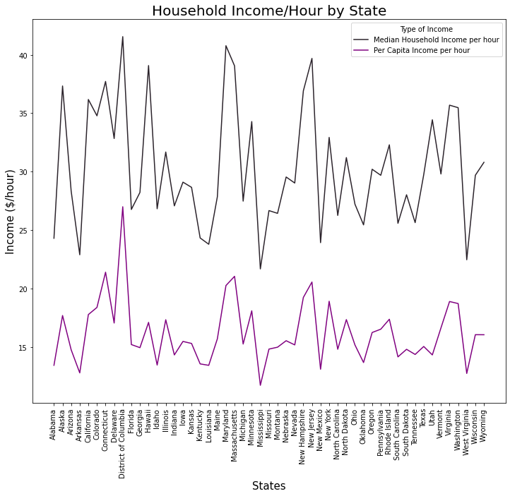

```python
#graphing median and per capita income for each state

state_income = states_demographic.drop(columns = ['Income.Median Houseold Income', 'Income.Per Capita Income'])
income_df = pandas.DataFrame(state_income)

income_df = pandas.melt(income_df, 'State', var_name = 'Type of Income', value_name = 'Income') #combining dataframe

#setting size of graph/rotating x-axis labels
plt.figure(figsize = (12,10))
plt.xticks(rotation = 90)
pal = sb.dark_palette("purple", 2) #setting colors for the lines

income_plot = sb.lineplot('State', 'Income', hue = 'Type of Income', data = income_df, palette = pal) #graphing lines

#label title and x, y axis
income_plot.set_title("Household Income/Hour by State", fontsize = 20)
income_plot.set_xlabel('States', fontsize = 15)
income_plot.set_ylabel('Income ($/hour)', fontsize = 15)
```

### Income Analysis

With the median household and per capita income, we can see the two lines following a similar trend. This is expected Per capita is calculated by dividing total income by total population. Whereas, median household income is calculated used the median of all household incomes. It is expected that per capita income is less than median household income because the total population is taken into account when calculating income.

## Data Analysis for Living Wage

Although it would be nice to analyze the data for each state and each specific family structure, for the ease of analyzing and comprehending the data, I decided to find the average of each family structure. To do this, I created a new column for each general family structure (one adult, two adults but only one works, two adults and both work). The new column was labeled $avg\_livingwage$.

I totaled each family structure based on the number of adults (ex: oneadult_onekid, oneadult_twokids, oneadult_threekids were added together for each state) and then divided by three to get the average. The average given by the previous calculation was added to $avg\_livingwage$.

```python
#finding average for each family structure based on number of adults working

#average of living wage for one adult working
oneadult_livingwage = living_wage[['state_territory', 'oneadult_onekid', 'oneadult_twokids', 'oneadult_threekids']]
oneadult_livingwage = oneadult_livingwage.set_index(oneadult_livingwage['state_territory'])
oneadult_livingwage['avg_livingwage'] = (oneadult_livingwage['oneadult_onekid'] + oneadult_livingwage['oneadult_twokids'] + oneadult_livingwage['oneadult_threekids']) / 3.0

#average of living wage for two adults but only one working
twoadults_oneworking_livingwage = living_wage[['state_territory', 'twoadults_oneworking_onekid', 'twoadults_oneworking_twokids', 'twoadults_oneworking_threekids']]
twoadults_oneworking_livingwage = twoadults_oneworking_livingwage.set_index(twoadults_oneworking_livingwage['state_territory'])
twoadults_oneworking_livingwage['avg_livingwage'] = (twoadults_oneworking_livingwage['twoadults_oneworking_onekid'] + twoadults_oneworking_livingwage['twoadults_oneworking_twokids'] + twoadults_oneworking_livingwage['twoadults_oneworking_threekids']) / 3.0

#average of living wage for two adults, both working
twoadults_livingwage = living_wage[['state_territory', 'twoadults_bothworking_onekid', 'twoadults_bothworking_twokids', 'twoadults_bothworking_threekids']]
twoadults_livingwage = twoadults_livingwage.set_index(twoadults_livingwage['state_territory'])
twoadults_livingwage['avg_livingwage'] = (twoadults_livingwage['twoadults_bothworking_onekid'] + twoadults_livingwage['twoadults_bothworking_twokids'] + twoadults_livingwage['twoadults_bothworking_threekids']) / 3.0
```

I decided to graph the average for each family structure out before continuing with any further data analysis. This would help to clarify each graph.

I will be plotting the income graph on top of the average living wage graphs to provide a comparison. This will be used in the analysis later in the project.

### Graph for Families with One Adult

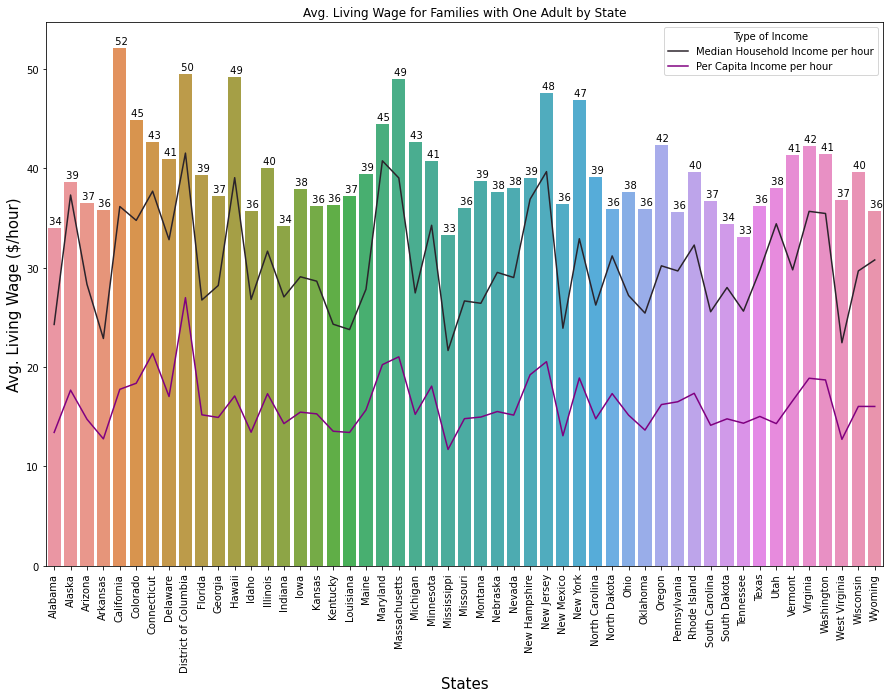

```python
#graphing one adult families

#create a dataframe from the oneadult_livingwage Series
oneadult_df = pandas.DataFrame(oneadult_livingwage)

#plot the graph for one adult families
plt.figure(figsize = (15,10))
sb.lineplot('State', 'Income', hue = 'Type of Income', data = income_df, palette = pal) #graphing lines
oneadult_plot = sb.barplot(x = "state_territory", y = "avg_livingwage", data = oneadult_df)

#label title and x, y axis
oneadult_plot.set_title("Avg. Living Wage for Families with One Adult by State")
oneadult_plot.set_xlabel('States', fontsize = 15)
oneadult_plot.set_ylabel('Avg. Living Wage ($/hour)', fontsize = 15)

#rotate x axis labels for ease of reading
oneadult_plot.set_xticklabels(oneadult_plot.get_xticklabels(), rotation = 90)

#add avg. living wage above each bar
for val in oneadult_plot.patches:
    oneadult_plot.annotate(format(val.get_height(), '3.0f'),
                   (val.get_x() + val.get_width() / 2.0, val.get_height()),
                   ha = 'center', va = 'center',
                   xytext = (0, 7),
                   fontsize = 10,
                   textcoords = 'offset points')
```

### Graph for Families with Two Adults (but only one working)

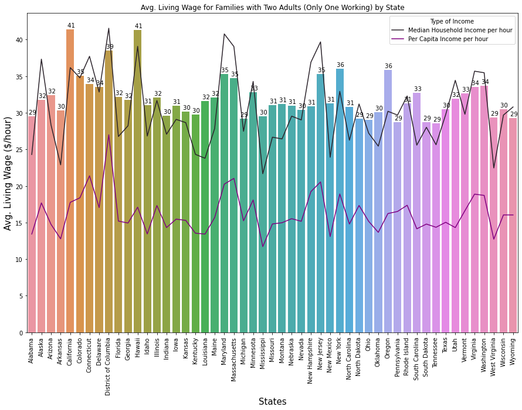

```python
#graphing families with two adults but only one works

#create a dataframe from the twoadults_oneworking_livingwage Series
twoadults_onework_df = pandas.DataFrame(twoadults_oneworking_livingwage)

#plot the graph for two adults, only one works families
plt.figure(figsize = (15,10))
sb.lineplot('State', 'Income', hue = 'Type of Income', data = income_df, palette = pal) #graphing lines
twoadult_onework_plot = sb.barplot(x = "state_territory", y = "avg_livingwage", data = twoadults_onework_df)

#label title and x, y axis
twoadult_onework_plot.set_title("Avg. Living Wage for Families with Two Adults (Only One Working) by State")
twoadult_onework_plot.set_xlabel('States', fontsize = 15)
twoadult_onework_plot.set_ylabel('Avg. Living Wage ($/hour)', fontsize = 15)

#rotate x axis labels for ease of reading
twoadult_onework_plot.set_xticklabels(twoadult_onework_plot.get_xticklabels(), rotation = 90)

#add avg. living wage above each bar
for val in twoadult_onework_plot.patches:
    twoadult_onework_plot.annotate(format(val.get_height(), '3.0f'),
                   (val.get_x() + val.get_width() / 2.0, val.get_height()),
                   ha = 'center', va = 'center',
                   xytext = (0, 7),
                   fontsize = 10,
                   textcoords = 'offset points')
```

### Graph for Families with Two Adults (both working)

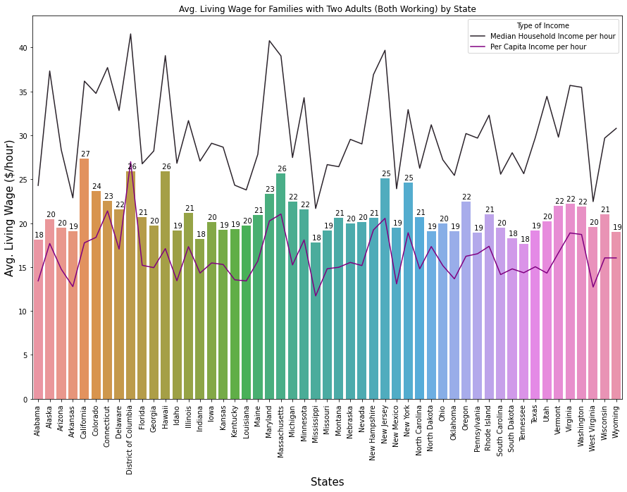

```python
#graphing families with two adults, both work

#create a dataframe from the oneadult_livingwage Series
twoadults_df = pandas.DataFrame(twoadults_livingwage)

#plot the graph for one adult families
plt.figure(figsize = (15,10))
sb.lineplot('State', 'Income', hue = 'Type of Income', data = income_df, palette = pal) #graphing lines
twoadults_plot = sb.barplot(x = "state_territory", y = "avg_livingwage", data = twoadults_df)

#label title and x, y axis
twoadults_plot.set_title("Avg. Living Wage for Families with Two Adults (Both Working) by State")
twoadults_plot.set_xlabel('States', fontsize = 15)
twoadults_plot.set_ylabel('Avg. Living Wage ($/hour)', fontsize = 15)

#rotate x axis labels for ease of reading
twoadults_plot.set_xticklabels(twoadults_plot.get_xticklabels(), rotation = 90)

#add avg. living wage above each bar
for val in twoadults_plot.patches:
    twoadults_plot.annotate(format(val.get_height(), '3.0f'),
                   (val.get_x() + val.get_width() / 2.0, val.get_height()),
                   ha = 'center', va = 'center',
                   xytext = (0, 7),
                   fontsize = 10,
                   textcoords = 'offset points')
```

## Analysis of Living Wages

As seen through the three graphs for each family structure, the average living wage differs greatly. The overall average is highest for families with one adult working. The lowest average living wage is for families with both parents working.

We can relate this to the possibility of both parents working lower wage jobs.

In the graphs, I can see that the states with the highest living wages (California, District of Columbia, Hawaii, Massachusetts, New Jersey, New York) remain consistent.

We also have to keep in mind that this data analysis is not extensive enough to draw concrete conclusions. The living wage of each family structure has been averaged out. So there may be some error when there are drastic differences in living wage depending on the number of children in the family. Also, families with more than three children are not accounted for in the original dataset. Therefore, families with more than three children are not accounted for in the graphs or analysis.

## Data Analysis for Poverty Rates

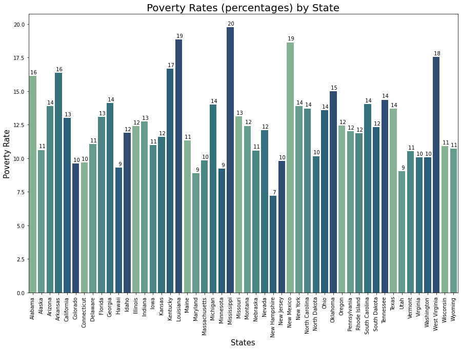

```python
poverty_df = pandas.DataFrame(poverty_states)

#setting size of graph/rotating x-axis labels
plt.figure(figsize = (15,10))
plt.xticks(rotation = 90)

poverty_plot = sb.barplot(data = poverty_df, x = 'State', y = 'Poverty Rate (percent)', palette = sb.color_palette("crest")) #graphing lines

#label title and x, y axis
poverty_plot.set_title("Poverty Rates (percentages) by State", fontsize = 20)
poverty_plot.set_xlabel('States', fontsize = 15)
poverty_plot.set_ylabel('Poverty Rate', fontsize = 15)

for val in poverty_plot.patches:
    poverty_plot.annotate(format(val.get_height(), '3.0f'),
                   (val.get_x() + val.get_width() / 2.0, val.get_height()),
                   ha = 'center', va = 'center',
                   xytext = (0, 7),
                   fontsize = 10,
                   textcoords = 'offset points')
```

Surprisingly, the poverty rates do not correlate to the living wages and incomes. The highest living wages (California, Hawaii, Massachusetts, New Jersey, New York) do not have the highest poverty rates. The states with the highest poverty rates are Kentucky, Louisiana, Mississippi, New Mexico, and West Virginia.

This is different from my prediction because I thought that the states with the higher living wages would have higher poverty rates due to wage inequalities and cost of basic necessities.

## Linear Regression

In this section, I will be exploring the relationship between poverty rates and the average living wages that were calculated above. My hypothesis is that there is not a large relationship between the two. Due to the different family structures that can be used, I used a multiple linear regression to test the hypothesis out.

The independent variables are the family structures: one adult, two adults with one working, two adults with both working. The dependent variable is the poverty rate.

```python
#combining all average wage tables for linear regression
all_avg_livingwage = pandas.DataFrame()
all_avg_livingwage['oneadult_avg'] = oneadult_livingwage['avg_livingwage']
all_avg_livingwage['twoadults_onework_avg'] = twoadults_oneworking_livingwage['avg_livingwage']
all_avg_livingwage['twoadults_avg'] = twoadults_livingwage['avg_livingwage']

all_avg_livingwage.drop('District of Columbia', inplace = True) #the poverty rates data set does not include District of Columbia

all_avg_livingwage.head()
```

| state_territory | oneadult_avg | twoadults_onework_avg | twoadults_avg |
| --- | --- | --- | --- |
| Alabama | 34.053333 | 29.490000 | 18.143333 |
| Alaska | 38.603333 | 31.783333 | 20.460000 |
| Arizona | 36.570000 | 32.413333 | 19.503333 |
| Arkansas | 35.853333 | 30.296667 | 19.073333 |
| California | 52.120000 | 41.390000 | 27.360000 |

```python
#family structure average for training/testing data
X_train = all_avg_livingwage[['oneadult_avg', 'twoadults_onework_avg', 'twoadults_avg']]
y_train = list(poverty_states['Poverty Rate (percent)'])

X_test = all_avg_livingwage[['oneadult_avg', 'twoadults_onework_avg', 'twoadults_avg']]
y_test = list(poverty_states['Poverty Rate (percent)'])
```

```python
lin_reg = LinearRegression().fit(X_train, y_train)
```

```
R_Squared Score:  0.21337350614368011
```

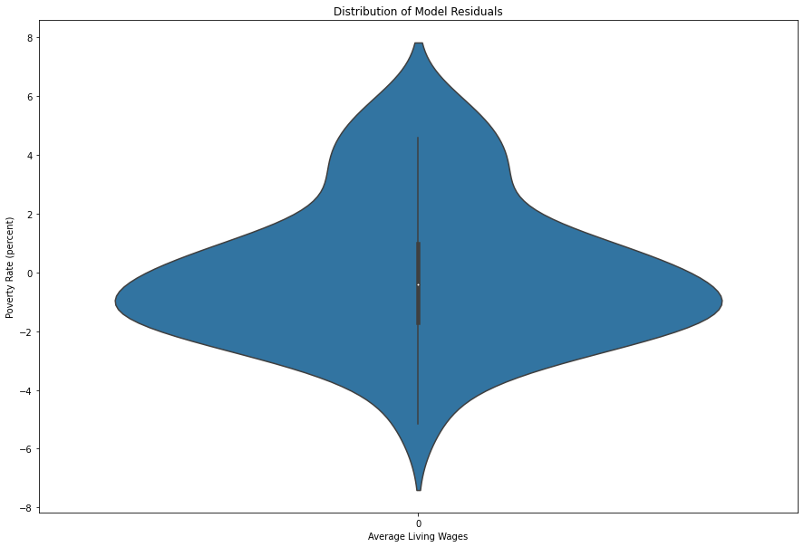

```python
# Get the R squared value
r_2 = lin_reg.score(X_test, y_test)

# Calculate the residual values of the actual vs predicted values
y_pred = lin_reg.predict(X_test)
residuals = y_test - y_pred

# Make the violin plot of the residual values
fig = plt.gcf()
fig.set_size_inches(15, 10)
ax = sb.violinplot(data = residuals)
ax.set(title = 'Distribution of Model Residuals')
ax.set(xlabel = 'Average Living Wages', ylabel = 'Poverty Rate (percent)')

print("R_Squared Score: ", r_2)
```

I also looked at the R^2 result which represents the variation of the model. It is a low 20%, meaning that this is not as accurate of a representation.

We can also assume that the linear regression is not exact because the living wages are all averaged out.

## Conclusion

Before doing the project, I had the assumption that higher living wages would correlate to higher income rates. This held true during my analysis and graphing. However, my assumption of higher living wages and higher poverty rates did not hold true.

In the future, I would like to expand this project to the international level with different countries.